# Genome Size Estimation Tutorial

# Tutorial Outline

1. How can K-mer estimation help to find genome sizes?
2. k-mer Distribution of a Typical Real World Genome
   1. k-mer size
   2. Counting k-mers in different genomes
   3. Workflow
3. Count k-mer occurrence in a bacteria using Jellyfish 2.2.10
4. Generate histogram using R
5. Determine the single copy region and the total k-mers
6. Determine peak position and genome size
7. Compare the peak shape with Poisson distribution
8. GenomeScope

# 1. How can K-mer estimation help to find genome sizes?

For a given sequence of length L, and a k-mer size of k, the total number of k-mer’s possible will be given by __( L – k ) + 1__  
e.g. In a sequence of length of 14, and a k-mer length of 8, the number of k-mer’s generated will be:

```
# GATCCTACTGATGC (L) on decomposition of k-mers of length (k),
    L = 14;  k = 8;

 # Total number of k-mer's generated will be

  n    = ( L - k ) + 1
       = (14 - 8 ) + 1
       = 7
```

GATCCTAC, ATCCTACT,TCCTACTG,CCTACTGA,CTACTGAT,TACTGATG,ACTGATGC

For shorter fragment sizes, as in the above example, the Total number of k-mers estimated is n = 7, and it is not close to actual fragment size of L which is 14 bps. But for larger fragment size, the total number of k-mer’s (n) provide a good approximation to the actual genome size. The following table tries to illustrate the approximation:

| Genome Sizes (L) | Total K-mers of k=18 N=(L-K)+1 | % error in genome estimation |
| --- | --- | --- |
| 100 | 83 | 17 |
| 1000 | 983 | 1.7 |
| 10000 | 9983 | 0.17 |
| 100000 | 99983 | 0.017 |
| 1000000 | 999983 | 0.0017 |

So for a genome size of 1 Mb, the error between estimation and reality is only .0017%. Which is a very good approximation of actual size.

Let's say your genome consists of 10 copies (C) of the sequence GATCCTACTGATGC. Then the total number of k-mer’s (n) of length k = 8 will be 70.

```
n    = [( L - k ) + 1 ] * C
       = [(14 - 8 ) + 1] * 10
       = 70
```

In this case we've overestimated the genome size because there were ten identical copies of the genome. To get the actual genome size, we simply need to divide the total kmers by the number of copies:

```
= n / C
       = 70 / 10
       = 7
```

# 2. k-mer Distribution of a Typical Real World Genome

High throughput sequencing enables the sequencing of novel genomes on a daily basis. However, even the most basic characteristics of these genomes, such as their size or heterozygosity rate, may be initially unknown A major issue that is faced in real world genome sequencing projects is non-uniform coverage of genome. This can be accounted to technical and biological variables.  
Example: biased amplification of certain genomic regions during PCR (a step in preparation of sequencing libraries) and presence of repetitive sequences in genome.

## A. k-mer size:

The size of k-mers should be large enough allowing the k-mer to map uniquely to the genome (a concept used in designing primer/oligo length for PCR). Too large k-mers leads to overuse of computational resources.

In the first step, k-mer frequency is calculated to determine the coverage of genome achieved during sequencing. There are software tools like **[Jellyfish](http://www.cbcb.umd.edu/software/jellyfish/)** that helps in finding the k-mer frequency in sequencing projects. The k-mer frequency follows a pseudo-normal distribution (actually it is a Poisson distribution) around the mean coverage in the histogram of k-mer counts.

Once the k-mer frequencies are calculated, a histogram is plotted to visualize the distribution and to calculate mean coverage.

[figure not shown]

Figure 1: An example of a k-mer histogram. The x-axis (V1), is the frequency or the number of times a given k-mer is observed in the sequencing data. The y-axis (V2), is the total number of k-mers with a given frequency.

The first peak (in red region) is primarily due to rare and random sequencing errors in reads. The values in the graph can be trimmed to remove reads with sequencing errors.

[figure not shown]

With the assumption that k-mers are uniquely mapped to the genome, they should be present only once in a genome sequence. So their frequency will reflect the coverage of the genome.

For calculation purposes we use the mean of the coverage which is 14 in above graph. The area under the curve will represent the total number of k-mers.

So the genome estimation will be:

```
N = Total no. of k-mers/Coverage
      = Area under curve /mean coverage(14)
```

## B. Counting k-mers in genomes

In organisms with **diploid** genomes, k-mers are generated from both homologous chromosomes and counting k-mers in regions of the genome where there is not genetic variation will result in k-mers being counted at a rate of 2X the read coverage. In heterozygous regions of the genome, k-mer sequences are unique to the polymorphism on a particular chromosome and these k-mers are counted at a rate of 1X read coverage. Below is a figure that depicts how heterozygous sites (red and green) in a genome changes the coverage of k-mers compared to homozygous regions (blue).

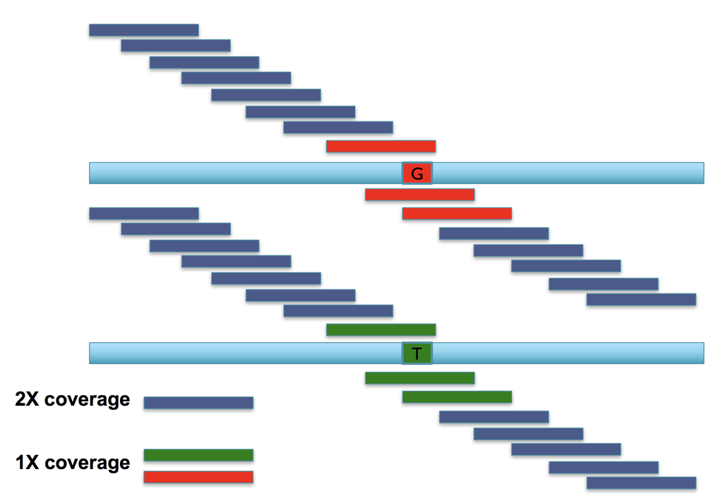

Often in sequencing project, we do not know the heterozygosity of an organism but heterozygosity creates a characteristics "double" peak in the k-mer profile and the ratio of single (1X) to double (2X) copy k-mers can be used to estimate heterozygosity. Below is a figure that depicts the single and double copy peaks for organisms with different levels of heterozygosity. Note that low heterozygosity results in more double copy k-mers and high heterozygosity results in more single copy peaks.

[figure not shown]

In organisms with **haploid** genomes (*i.e.* most bacteria), mapping k-mers is slightly different because these genomes have only a single circular chromosome and essentially zero heterozygosity. As a result, the k-mer profiles will be primarily dominated by a large peak representing the single copy (1X) or haploid part of the genome. It should be noted that a slight shoulder peak on the right can occur and this could represent repetitive regions of the genome or genes the were recently duplicated.

## C. Workflow

The study was conducted to estimate the genome size of the species with low coverage short read data to validate existing estimates (flow cytometry sourced) or produce a new computational estimate. The genome size is calculated from short sub-sequences (k-mers) of Illumina short read data. A larger k-mer size needs to be considered for the genome estimation.

Reads should be quality controlled before the genome estimate is provided. Numerous programs exist for this purpose but Sickle (https://github.com/ucdavis-bioinformatics/sickle) is the application of choice in this tutorial. We require a minimum Phred-scaled quality value of 25-30 for estimates.

Upon performing quality control, the k-mer distribution was calculated using the Jellyfish k-mer counting program. Then a histogram was constructed to perform the genome estimation using the same program.

The R statistical package is used to plot the binned distributions for the selected k-mer lengths. Initally the full data set is plotted and initial data points are often very high number due to the low frequency data points, and thus it should be avoided. Once the peak position is determined the total number of k-mers in the distribution is calculated, and then the genome size can be estimated using the peak position. In the ideal situation (or theoretically) the peak shape should be a Poisson distribution. In order to come up with a k-mer size a number of k-mer sizes are selected and genome estimation is done, where we see a regular distribution of the genome size.

# 3. Count k-mer occurrence in a bacteria using Jellyfish 2.2.10

To begin this exercise, we need to determine where the data sets are available on the server:

```
Path: /home/WWU/BIOL497R/data/jellyfish/
Data sets: SRR292770_1.fastq   SRR292770_2.fastq
```

To run `jellyfish`, you can use the command below or open a ssh terminal connection to the class server, navigate to working directory, and execute the follwoing BASH command:

```python
%%bash

#location of sequence data
DATA=/home/WWU/BIOL497R/data/jellyfish/

jellyfish count -t 3 -C -m 14 -s 5G -o 14mer_out --min-qual-char=? \
        $DATA/SRR292770_1.fastq $DATA/SRR292770_2.fastq
```

options used in the counting k-mers:

> -t -treads=unit32 Number of treads to be used in the run. eg: 1,2,3,..etc  
> -C -both-strands Count both strands  
> -m -mer-len=unit32 Length of the k-mer  
> -s -size=unit32 Hash size / memory allocation  
> -o -output=string Output file name  
> --min-quality-char Base quality value. Version 2.2.10 of Jellyfish uses the “Phred” score, where "?" = 30

If you need to look at a detailed usage of ‘count’ in jellyfish, type the following commands into a command line:

> jellyfish [options]  
> jellyfish count --help  
> jellyfish count --full-help

Once the run is complete jellyfish will create a output (**`-o`**) file called `14mer_out`. Then using the above created file (14mer_out), data points for a histogram will be created using the following command:

```python
%%bash

jellyfish histo -o 14mer_out.histo 14mer_out
```

If you open the .histo file **`head 14mer_out.histo`**, it will have the frequency counting of each k-mer with the k-mer length of 14.

```python
%%bash

head -n 20 14mer_out.histo
```

```
1 11701547
2 1440988
3 173094
4 23576
5 4701
6 2478
7 2668
8 3463
9 4370
10 5323
11 6526
12 8185
13 9936
14 11847
15 14497
16 17071
17 20051
18 22824
19 26612
20 30518
```

# 4. Generate histogram using R

To visualize and to plot the data we use R Studio. Using the following command, we will load the data from the out_14mer.histo file in to a data frame called dataframe14.

[figure not shown]

```python
%%R

dataframe14 <- read.table("14mer_out.histo") #load the data

plot(dataframe14[1:200,], type="l") #plots the data points 1 through 200 in the dataframe14 using a line

abline(v = 10, col="blue") #blue represents potential boundry between sequencing errors (left) and real k-mers (right)
```

In general, very low frequency k-mers (1:10) represent sequencing errors and high numbers that would skew the y–axis. If we look at the data points in the histogram file, we can see that the very first data point has a exceptionally high value than the next (second) data point. So we remove just the first few lines and re-plot using R. From now on we will disregard the first few data points for our calculations.

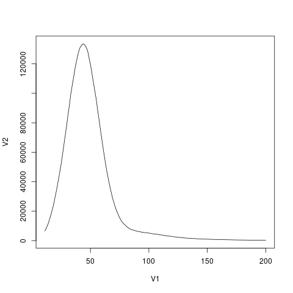

```python
%%R

plot(dataframe14[11:200,], type="l")
```

# 5. Determine the single copy region and the total number of k-mers

To determine the cut off points in the single copy region, we need to see the actual data point positions in the graph. In the initial examination the peak starts from the 11th data point onward. So we will disregard data points 1 to 10 in determining the single copy region and we don't want to include the right tail because that would represent double copy k-mers.

Now using R we will re-plot the graph to determine the single copy region. Then we will include the points for clarity on the same graph.

[figure not shown]

```python
%%R

plot(dataframe14[11:200,], type="l") #plot line graph

points(dataframe14[11:200,]) #plot the data points from 2 through 200

abline(v = c(11,80), col="red") #reds represent potential boundries of single copy region
```

According to the graph, the single copy region would be between points 11 and 80.

```python
%%R

n = nrow(dataframe14)

sum(as.numeric(dataframe14[11:n,1]*dataframe14[11:n,2]))
```

```
[1] 242384628
```

# 6. Determine peak position and genome size

From the plotted graph we can get an idea where the peak position lies, and it should be between 35-55 data points. Now to determine the peak, thus, we need to look at the actual data points in that region. Using the below command we will examine the actual data points between 35 and 55.

```python
%%R

dataframe14[35:55,]
```

```
   V1     V2
35 35 108058
36 36 112875
37 37 117894
38 38 121401
39 39 125342
40 40 128411
41 41 130911
42 42 132084
43 43 133346
44 44 133554
45 45 132929
46 46 131703
47 47 130129
48 48 127513
49 49 123156
50 50 119657
51 51 114952
52 52 109919
53 53 105177
54 54 100541
55 55  95677
```

In this case it looks like the peak is at, 44. We can confirm this using the max function.

```python
%%R

dataframe14$V1[dataframe14$V2 == max(dataframe14[35:55,2])]
```

[output not shown]

So the Genome Size can be estimated as:

```python
%%R

# lambda is our estimate of the mean coverage
lambda = 44

n = nrow(dataframe14)

(totalGenome = sum(dataframe14[11:n,1]*dataframe14[11:n,2])/lambda)
```

```
[1] 5508742
```

It would be interesting to see the proportionality of the single copy region compared to the total genome size. In this data set the single copy region is between data point 11 and 80, So the size of single copy region can be roughly calculated as:

```python
%%R

(singleCopy = sum(as.numeric(dataframe14[11:80,1]*dataframe14[11:80,2]))/lambda)
```

```
[1] 4663942
```

The proportion can be calculated as:

```python
%%R

singleCopy / totalGenome
```

```
[1] 0.8466437
```

# 7. Compare the peak shape with Poisson distribution

Since we have a nice curve, we can compare our single copy curve to a theoretical curve, which is the Poission distribution. **Note**, we don't want to compare the total genome to a Poisson distribution because the total genome would be a mixture of multiple distributions.

The original mathmatical models for estimating genome size were based on a Poisson distribution but this approach has changed because real sequencing data is often over-dispersed compared to a Poisson distribution (as seen below) and bimodal (see section 2B).

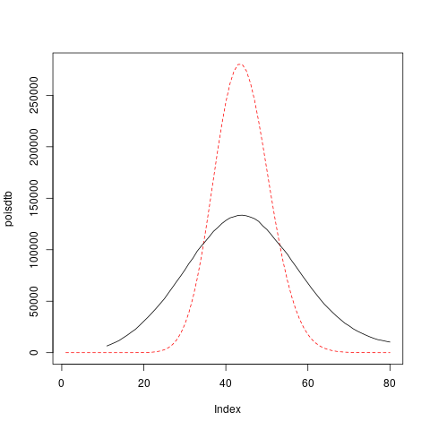

```python
%%R

#poission distribution
poisdtb <- dpois(1:80,lambda)*singleCopy

plot(poisdtb, type='l', lty=2, col="red")

#k-mer distribution
lines(dataframe14[11:80,lambda] * singleCopy, type = "l", col=3)

lines(dataframe14[11:80,],type= "l")
```

Likewise the procedure can be iterated across different k-mers lengths.

[output not shown]

# 8. GenomeScope

In this next section, we will use **[GenomeScope](http://qb.cshl.edu/genomescope/)** which fits a mixture model of four evenly spaced negative binomial distributions to the k-mer profile to measure the relative abundances of heterozygous and homozygous, unique or single (1X) and two-copy (2X) sequences.

[figure not shown]

#### Results - GenomeScope version 1.0

k = 14

| property | min | max |
| --- | --- | --- |
| Heterozygosity | 0.161481% | 0.175063% |
| Genome Haploid Length | 5,354,860 bp | 5,362,681 bp |
| Genome Repeat Length | 863,969 bp | 865,231 bp |
| Genome Unique Length | 4,490,891 bp | 4,497,450 bp |
| Model Fit | 95.0008% | 96.8218% |
| Read Error Rate | 0.504395% | 0.504395% |